# Project: The Movie Database[TMDB] Data Analysis

- Introduction
- Data Wrangling
- Exploratory Data Analysis
- Conclusions

## Introduction

```python
##-- The following packages are being imported for my data Analysis.
import numpy as np
import pandas as pd
import matplotlib.pyplot as plt
% matplotlib inline
import seaborn as sns
```

## Loading Data :

> > I have selected TMDb movie data to anlysis it and Explore my Questions. I am loading my TMDb movie data to start my analysis. I have defined df_mv variable to store TMDb movie data into dataframe. To perform to view the first sample 5 rows TMDb data.

```python
df_mv =pd.read_csv("tmdb-movies.csv")
df_mv.head()
```

|  | id | imdb_id | popularity | budget | revenue | original_title | cast | homepage | director | tagline | ... | overview | runtime | genres | production_companies | release_date | vote_count | vote_average | release_year | budget_adj | revenue_adj |
| --- | --- | --- | --- | --- | --- | --- | --- | --- | --- | --- | --- | --- | --- | --- | --- | --- | --- | --- | --- | --- | --- |
| 0 | 135397 | tt0369610 | 32.985763 | 150000000 | 1513528810 | Jurassic World | Chris Pratt\|Bryce Dallas Howard\|Irrfan Khan\|Vi... | http://www.jurassicworld.com/ | Colin Trevorrow | The park is open. | ... | Twenty-two years after the events of Jurassic ... | 124 | Action\|Adventure\|Science Fiction\|Thriller | Universal Studios\|Amblin Entertainment\|Legenda... | 6/9/15 | 5562 | 6.5 | 2015 | 1.379999e+08 | 1.392446e+09 |
| 1 | 76341 | tt1392190 | 28.419936 | 150000000 | 378436354 | Mad Max: Fury Road | Tom Hardy\|Charlize Theron\|Hugh Keays-Byrne\|Nic... | http://www.madmaxmovie.com/ | George Miller | What a Lovely Day. | ... | An apocalyptic story set in the furthest reach... | 120 | Action\|Adventure\|Science Fiction\|Thriller | Village Roadshow Pictures\|Kennedy Miller Produ... | 5/13/15 | 6185 | 7.1 | 2015 | 1.379999e+08 | 3.481613e+08 |
| 2 | 262500 | tt2908446 | 13.112507 | 110000000 | 295238201 | Insurgent | Shailene Woodley\|Theo James\|Kate Winslet\|Ansel... | http://www.thedivergentseries.movie/#insurgent | Robert Schwentke | One Choice Can Destroy You | ... | Beatrice Prior must confront her inner demons ... | 119 | Adventure\|Science Fiction\|Thriller | Summit Entertainment\|Mandeville Films\|Red Wago... | 3/18/15 | 2480 | 6.3 | 2015 | 1.012000e+08 | 2.716190e+08 |
| 3 | 140607 | tt2488496 | 11.173104 | 200000000 | 2068178225 | Star Wars: The Force Awakens | Harrison Ford\|Mark Hamill\|Carrie Fisher\|Adam D... | http://www.starwars.com/films/star-wars-episod... | J.J. Abrams | Every generation has a story. | ... | Thirty years after defeating the Galactic Empi... | 136 | Action\|Adventure\|Science Fiction\|Fantasy | Lucasfilm\|Truenorth Productions\|Bad Robot | 12/15/15 | 5292 | 7.5 | 2015 | 1.839999e+08 | 1.902723e+09 |
| 4 | 168259 | tt2820852 | 9.335014 | 190000000 | 1506249360 | Furious 7 | Vin Diesel\|Paul Walker\|Jason Statham\|Michelle ... | http://www.furious7.com/ | James Wan | Vengeance Hits Home | ... | Deckard Shaw seeks revenge against Dominic Tor... | 137 | Action\|Crime\|Thriller | Universal Pictures\|Original Film\|Media Rights ... | 4/1/15 | 2947 | 7.3 | 2015 | 1.747999e+08 | 1.385749e+09 |

5 rows × 21 columns

## TMDB Movie Data Wrangling Steps

> **Data Wrangling**: i have loaded my TMDB data and i will start doing my data cleaning process one by one as instructed as below. 1) Removing Unwanted columns which is really not required on my data analysis 2) To clean the Null values rows from the dataset. 3) To remove the duplication from the dataset. 4) To fix the data values as meaningful. 5) To fix the datatype if it is not relevent datatype in dataset. 6) To remame the column which is not relevent in Dataset.

```python
## -- To check my TMDB filesrows counts & column counts.
## Row count -10866 and column count -21
df_mv.shape
```

```
(10866, 21)
```

```python
## -- To find the statistics of my TMDB movie data.
df_mv.describe()
```

|  | id | popularity | budget | revenue | runtime | vote_count | vote_average | release_year | budget_adj | revenue_adj |
| --- | --- | --- | --- | --- | --- | --- | --- | --- | --- | --- |
| count | 10866.000000 | 10866.000000 | 1.086600e+04 | 1.086600e+04 | 10866.000000 | 10866.000000 | 10866.000000 | 10866.000000 | 1.086600e+04 | 1.086600e+04 |
| mean | 66064.177434 | 0.646441 | 1.462570e+07 | 3.982332e+07 | 102.070863 | 217.389748 | 5.974922 | 2001.322658 | 1.755104e+07 | 5.136436e+07 |
| std | 92130.136561 | 1.000185 | 3.091321e+07 | 1.170035e+08 | 31.381405 | 575.619058 | 0.935142 | 12.812941 | 3.430616e+07 | 1.446325e+08 |
| min | 5.000000 | 0.000065 | 0.000000e+00 | 0.000000e+00 | 0.000000 | 10.000000 | 1.500000 | 1960.000000 | 0.000000e+00 | 0.000000e+00 |
| 25% | 10596.250000 | 0.207583 | 0.000000e+00 | 0.000000e+00 | 90.000000 | 17.000000 | 5.400000 | 1995.000000 | 0.000000e+00 | 0.000000e+00 |
| 50% | 20669.000000 | 0.383856 | 0.000000e+00 | 0.000000e+00 | 99.000000 | 38.000000 | 6.000000 | 2006.000000 | 0.000000e+00 | 0.000000e+00 |
| 75% | 75610.000000 | 0.713817 | 1.500000e+07 | 2.400000e+07 | 111.000000 | 145.750000 | 6.600000 | 2011.000000 | 2.085325e+07 | 3.369710e+07 |
| max | 417859.000000 | 32.985763 | 4.250000e+08 | 2.781506e+09 | 900.000000 | 9767.000000 | 9.200000 | 2015.000000 | 4.250000e+08 | 2.827124e+09 |

```python
## -- structure of the data
##-- To find that each column datatype and row counts of my TMDB movie data.
df_mv.info()
```

```
<class 'pandas.core.frame.DataFrame'>
RangeIndex: 10866 entries, 0 to 10865
Data columns (total 21 columns):
id                      10866 non-null int64
imdb_id                 10856 non-null object
popularity              10866 non-null float64
budget                  10866 non-null int64
revenue                 10866 non-null int64
original_title          10866 non-null object
cast                    10790 non-null object
homepage                2936 non-null object
director                10822 non-null object
tagline                 8042 non-null object
keywords                9373 non-null object
overview                10862 non-null object
runtime                 10866 non-null int64
genres                  10843 non-null object
production_companies    9836 non-null object
release_date            10866 non-null object
vote_count              10866 non-null int64
vote_average            10866 non-null float64
release_year            10866 non-null int64
budget_adj              10866 non-null float64
revenue_adj             10866 non-null float64
dtypes: float64(4), int64(6), object(11)
memory usage: 1.7+ MB
```

## To begin with Data Cleaning Steps

> >

# Step :-1

###### #

# The following columns are not going to use on my data analysis .Hence i have removed this column from my dataframe.

# id

# imdbid

# homepage

# overview

# tagline

```python
df_mv.drop(['id', 'imdb_id', 'homepage', 'overview','tagline'], axis=1, inplace=True)
df_mv.info()
```

```
<class 'pandas.core.frame.DataFrame'>
RangeIndex: 10866 entries, 0 to 10865
Data columns (total 16 columns):
popularity              10866 non-null float64
budget                  10866 non-null int64
revenue                 10866 non-null int64
original_title          10866 non-null object
cast                    10790 non-null object
director                10822 non-null object
keywords                9373 non-null object
runtime                 10866 non-null int64
genres                  10843 non-null object
production_companies    9836 non-null object
release_date            10866 non-null object
vote_count              10866 non-null int64
vote_average            10866 non-null float64
release_year            10866 non-null int64
budget_adj              10866 non-null float64
revenue_adj             10866 non-null float64
dtypes: float64(4), int64(5), object(7)
memory usage: 1.3+ MB
```

```python
#Step :-2
##########
# To do checks if any of columns have null values
## returning true which means that have an null values into my data frame.
df_mv.isnull().sum().any()
```

```
True
```

## Communication :

> > The step 2 results shows me that there are null values is there in my dataframe. Now I have two Questiion here

## 1) is that entire row is having NULL values ?

## 2) Is that specific column only has NULL values ?

## Analysis decision :

> > I have decided to create a BAR chart to find my answers of this abvoe Qustions

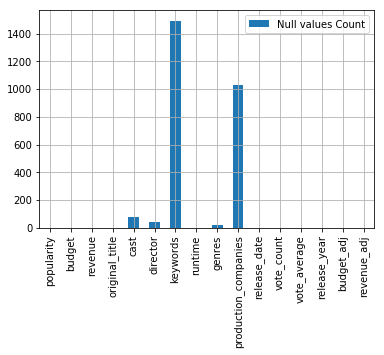

```python
#Step :-2.1
##########
# Let me visulaized the null values to find which columns shows null values
df_mv.isnull().sum().plot(kind='bar',grid=True,label ='Null values Count')
plt.legend()
```

## Results Communication :

```python
#Step :-3
##########
# I am going to drop NULL rows from my data frame.
df_mv.dropna(axis=0,inplace=True)
df_mv.info()
```

```
<class 'pandas.core.frame.DataFrame'>
Int64Index: 8667 entries, 0 to 10865
Data columns (total 16 columns):
popularity              8667 non-null float64
budget                  8667 non-null int64
revenue                 8667 non-null int64
original_title          8667 non-null object
cast                    8667 non-null object
director                8667 non-null object
keywords                8667 non-null object
runtime                 8667 non-null int64
genres                  8667 non-null object
production_companies    8667 non-null object
release_date            8667 non-null object
vote_count              8667 non-null int64
vote_average            8667 non-null float64
release_year            8667 non-null int64
budget_adj              8667 non-null float64
revenue_adj             8667 non-null float64
dtypes: float64(4), int64(5), object(7)
memory usage: 1.1+ MB
```

```python
#Step :-4
##########
#To perform the checks again if any of columns have null values -Return should be false
df_mv.isnull().sum().any()
```

```
False
```

```python
#Step :-5
##########
# To Validate if any duplicate rows into my dataframe
df_mv.duplicated().sum()
```

```
1
```

```python
#Step :-6
##########
##To remove the duplication by using the following function.
df_mv.drop_duplicates(inplace=True)
df_mv.duplicated().sum()
```

```
0
```

```python
#Step :-7 - Column Renaming
#########
## keyword column is not much meaningful to understand the columns data ,Hence i have changed as "properties".
df_mv.rename(columns={'keywords':'properties'}, inplace=True)
df_mv.info()
```

```
<class 'pandas.core.frame.DataFrame'>
Int64Index: 8666 entries, 0 to 10865
Data columns (total 16 columns):
popularity              8666 non-null float64
budget                  8666 non-null int64
revenue                 8666 non-null int64
original_title          8666 non-null object
cast                    8666 non-null object
director                8666 non-null object
properties              8666 non-null object
runtime                 8666 non-null int64
genres                  8666 non-null object
production_companies    8666 non-null object
release_date            8666 non-null object
vote_count              8666 non-null int64
vote_average            8666 non-null float64
release_year            8666 non-null int64
budget_adj              8666 non-null float64
revenue_adj             8666 non-null float64
dtypes: float64(4), int64(5), object(7)
memory usage: 1.1+ MB
```

## Communication :

> > Fixing the data values

###### #

> > The genres, properties,cast,columns,production_companies are separated by pipe (|) characters .

## Analysis decision:

> > So i have replaced with space characters for genres and Properties and cast. I have append with "and" for production_companies columns .Because we can understand and read it easly.

```python
#Step :-8 -
#=========
df_mv['genres']=df_mv['genres'].str.replace("|"," ")
df_mv['properties']=df_mv['properties'].str.replace("|"," ")
df_mv['cast']=df_mv['cast'].str.replace("|"," and ")
df_mv['production_companies']=df_mv['production_companies'].str.replace("|"," and ")
df_mv.head()
```

|  | popularity | budget | revenue | original_title | cast | director | properties | runtime | genres | production_companies | release_date | vote_count | vote_average | release_year | budget_adj | revenue_adj |
| --- | --- | --- | --- | --- | --- | --- | --- | --- | --- | --- | --- | --- | --- | --- | --- | --- |
| 0 | 32.985763 | 150000000 | 1513528810 | Jurassic World | Chris Pratt and Bryce Dallas Howard and Irrfan... | Colin Trevorrow | monster dna tyrannosaurus rex velociraptor island | 124 | Action Adventure Science Fiction Thriller | Universal Studios and Amblin Entertainment and... | 6/9/15 | 5562 | 6.5 | 2015 | 1.379999e+08 | 1.392446e+09 |
| 1 | 28.419936 | 150000000 | 378436354 | Mad Max: Fury Road | Tom Hardy and Charlize Theron and Hugh Keays-B... | George Miller | future chase post-apocalyptic dystopia australia | 120 | Action Adventure Science Fiction Thriller | Village Roadshow Pictures and Kennedy Miller P... | 5/13/15 | 6185 | 7.1 | 2015 | 1.379999e+08 | 3.481613e+08 |
| 2 | 13.112507 | 110000000 | 295238201 | Insurgent | Shailene Woodley and Theo James and Kate Winsl... | Robert Schwentke | based on novel revolution dystopia sequel dyst... | 119 | Adventure Science Fiction Thriller | Summit Entertainment and Mandeville Films and ... | 3/18/15 | 2480 | 6.3 | 2015 | 1.012000e+08 | 2.716190e+08 |
| 3 | 11.173104 | 200000000 | 2068178225 | Star Wars: The Force Awakens | Harrison Ford and Mark Hamill and Carrie Fishe... | J.J. Abrams | android spaceship jedi space opera 3d | 136 | Action Adventure Science Fiction Fantasy | Lucasfilm and Truenorth Productions and Bad Robot | 12/15/15 | 5292 | 7.5 | 2015 | 1.839999e+08 | 1.902723e+09 |
| 4 | 9.335014 | 190000000 | 1506249360 | Furious 7 | Vin Diesel and Paul Walker and Jason Statham a... | James Wan | car race speed revenge suspense car | 137 | Action Crime Thriller | Universal Pictures and Original Film and Media... | 4/1/15 | 2947 | 7.3 | 2015 | 1.747999e+08 | 1.385749e+09 |

```python
#Step :-7 - Column data type Fixing
###################################
### release date should not be string .So i have fixed the datatype for release date as date type.
df_mv['release_date'] =pd.to_datetime(df_mv['release_date'])
df_mv.info()
```

```
<class 'pandas.core.frame.DataFrame'>
Int64Index: 8666 entries, 0 to 10865
Data columns (total 16 columns):
popularity              8666 non-null float64
budget                  8666 non-null int64
revenue                 8666 non-null int64
original_title          8666 non-null object
cast                    8666 non-null object
director                8666 non-null object
properties              8666 non-null object
runtime                 8666 non-null int64
genres                  8666 non-null object
production_companies    8666 non-null object
release_date            8666 non-null datetime64[ns]
vote_count              8666 non-null int64
vote_average            8666 non-null float64
release_year            8666 non-null int64
budget_adj              8666 non-null float64
revenue_adj             8666 non-null float64
dtypes: datetime64[ns](1), float64(4), int64(5), object(6)
memory usage: 1.1+ MB
```

```python
###--To find the rows count and column count after cleaning the data.
df_mv.shape
```

```
(8666, 16)
```

```python
###--To see the sample data after cleaning the data.
df_mv.head()
```

|  | popularity | budget | revenue | original_title | cast | director | properties | runtime | genres | production_companies | release_date | vote_count | vote_average | release_year | budget_adj | revenue_adj |
| --- | --- | --- | --- | --- | --- | --- | --- | --- | --- | --- | --- | --- | --- | --- | --- | --- |
| 0 | 32.985763 | 150000000 | 1513528810 | Jurassic World | Chris Pratt and Bryce Dallas Howard and Irrfan... | Colin Trevorrow | monster dna tyrannosaurus rex velociraptor island | 124 | Action Adventure Science Fiction Thriller | Universal Studios and Amblin Entertainment and... | 2015-06-09 | 5562 | 6.5 | 2015 | 1.379999e+08 | 1.392446e+09 |
| 1 | 28.419936 | 150000000 | 378436354 | Mad Max: Fury Road | Tom Hardy and Charlize Theron and Hugh Keays-B... | George Miller | future chase post-apocalyptic dystopia australia | 120 | Action Adventure Science Fiction Thriller | Village Roadshow Pictures and Kennedy Miller P... | 2015-05-13 | 6185 | 7.1 | 2015 | 1.379999e+08 | 3.481613e+08 |
| 2 | 13.112507 | 110000000 | 295238201 | Insurgent | Shailene Woodley and Theo James and Kate Winsl... | Robert Schwentke | based on novel revolution dystopia sequel dyst... | 119 | Adventure Science Fiction Thriller | Summit Entertainment and Mandeville Films and ... | 2015-03-18 | 2480 | 6.3 | 2015 | 1.012000e+08 | 2.716190e+08 |
| 3 | 11.173104 | 200000000 | 2068178225 | Star Wars: The Force Awakens | Harrison Ford and Mark Hamill and Carrie Fishe... | J.J. Abrams | android spaceship jedi space opera 3d | 136 | Action Adventure Science Fiction Fantasy | Lucasfilm and Truenorth Productions and Bad Robot | 2015-12-15 | 5292 | 7.5 | 2015 | 1.839999e+08 | 1.902723e+09 |
| 4 | 9.335014 | 190000000 | 1506249360 | Furious 7 | Vin Diesel and Paul Walker and Jason Statham a... | James Wan | car race speed revenge suspense car | 137 | Action Crime Thriller | Universal Pictures and Original Film and Media... | 2015-04-01 | 2947 | 7.3 | 2015 | 1.747999e+08 | 1.385749e+09 |

## Communication :

> > I am going to analyse and visulize my movie data for the Year [1991-2000] .So it should be repetive code and used for more analysis work.

## Analysis decision:

> > So i have created a function to aviod this repetative Code.

```python
##function is created to avoid the repeated code to analyse my movie data for the Year [1991-2000].
def df_mv_year_filter(from_year, to_year):
    df_mv_1991_2000 = df_mv.query('release_year >%s and release_year <=%s'%(from_year, to_year));
    return(df_mv_1991_2000)
## --To call the function to check whether it will return the right results.
df_mv_year_filter(1990,2000).release_year.unique()
```

```
array([1999, 1994, 1997, 1995, 1992, 1996, 2000, 1998, 1991, 1993])
```

## Communication :

> > To draw a entire column statistical summary from my dataframe.

## Analysis decision:

> > So i have used Histogram diagram to see all my columns statistical summary.

[output not shown]

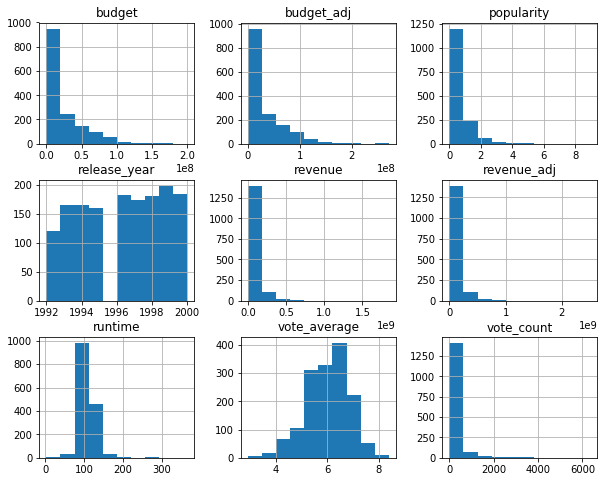

```python
##- To draw a histogram to get the statistics of each column data.
df_mv_year_filter(1991,2000).hist(figsize=(10,8))
```

## Plot decision:

> > first i bring that 10 years data and draw a 1D histogram diagaram to find my results.

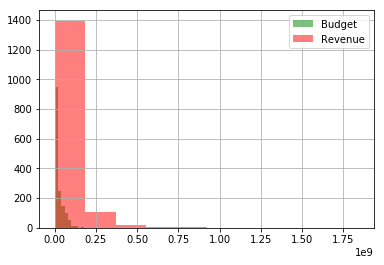

```python
df_mv_year_flt=df_mv_year_filter(1991,2000)
df_mv_year_flt["budget"].hist(alpha=0.5 ,label='Budget',color='green')
df_mv_year_flt["revenue"].hist(alpha=0.5 ,label='Revenue',color='red')
plt.legend();
```

## Exploratory My TMDB data file Analysis

### Research Question 1 (Which genres are most popular in 2000 year? )

### Communication :

> > For this Question first i have selected only 2000 Years Movie data to get the most popular genres on this year. I have fetched only few columns for my data analyis and assigned into df_sel_col data frame.

## Plot decision:

> > I have choosen Barh plot to visual my analyse data. I have used xlabel ='Ratings' and ylabel ='genres Name'

```python
df_mv_2000 =df_mv.query('release_year==2000')

df_sel_col =df_mv_2000.loc[:,['genres','popularity']]

##To get the most popularity for this 2000 Year.
df_sel_col.groupby(['genres']).popularity.max()

df_sel_col.head(10)
```

|  | genres | popularity |
| --- | --- | --- |
| 8661 | Action Drama Adventure | 4.271452 |
| 8662 | Mystery Thriller | 3.095625 |
| 8663 | Family Comedy Fantasy | 2.977558 |
| 8664 | Adventure Drama | 2.197205 |
| 8665 | Thriller Crime | 2.153361 |
| 8666 | Adventure Action Thriller | 1.956406 |
| 8667 | Fantasy Comedy Romance | 1.889388 |
| 8668 | Comedy | 1.815244 |
| 8669 | Adventure Animation Comedy Family Fantasy | 1.768463 |
| 8670 | Comedy Romance | 1.767681 |

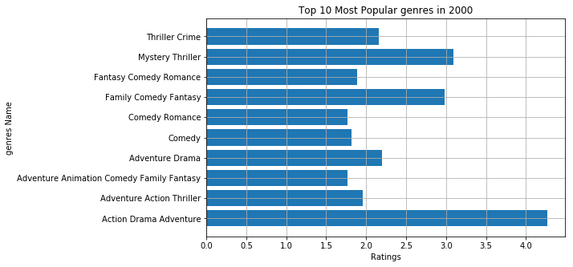

```python
## i am sorting the release year values to view my visulization in a proper order.
df_sel_rows =df_sel_col.head(10)
df_sel_rows.sort_values(['popularity'], ascending=False,inplace=True)

## Drawing steps as below
plt.subplots(figsize=(8, 5))
plt.barh(df_sel_rows.genres, df_sel_rows.popularity)
plt.title('Top 10 Most Popular genres in 2000')
plt.xlabel('Ratings')
plt.ylabel('genres Name');
plt.legend()
plt.grid(True)
plt.show()
```

### Research Question 2 (What kinds of properties are associated with movies that have high revenues? )

### Communication :

> > For this Qustions ,I have choosen properties columns as is one of the properties on every Movies. To do this , I will fetch Top 10 highest revenues from each properties and get the highest revenue from each properties.

## Plot decision:

> > I have choosen Barh plot to visual my analyse data. I have used xlabel ='revenue' and ylabel ='properties'

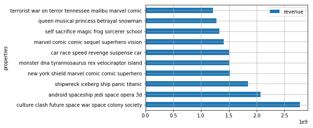

```python
rev_max=df_mv.groupby(['properties']).revenue.max()
df_rev_max=pd.DataFrame(rev_max)

##-- Sorting revenue columns to get the Top highest revenue order from each properties
df_rev_max.sort_values(['revenue'], ascending=False,inplace=True)

##-- Fetch only 10 rows to show the top 10 highest revenue from each properties.
df_rev_max.head(10).plot(kind='barh',grid=True)
```

## Plot decision:

> > I have choosen Bar plot to visual my analyse data. I have used xlabel ='genres' and ylabel ='runtime'

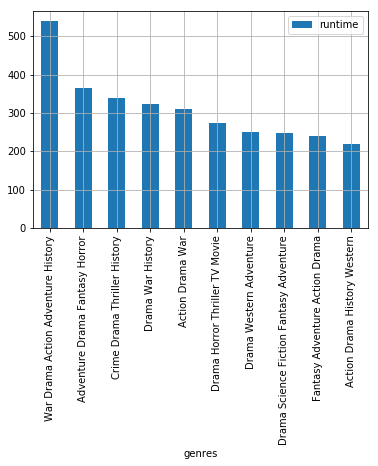

```python
avg_mv =df_mv.groupby(['genres']).runtime.mean()
df_avg_mv=pd.DataFrame(avg_mv)

##--Sorting with descending order to get the top 10 average highest run time
df_avg_mv.sort_values(['runtime'], ascending=False,inplace=True)
##- selecting the 10 rows from the data frame and draw it as below.
df_avg_mv.head(10).plot(kind='bar',grid=True)
```

### Research Question 4 (Display highest profitable and highest loss movies )

### Communication :

## --in order to get the profitable for each movies , I will do minus[revenue_adj and budget_adj].I will add one new columns like "profit" into Df_MV data frame to show the profit.

## Plot decision:

> > I have choosen Bar plot to visual my analyse data with subplot option. I have used xlabel ='Movie Name' and ylabel ='profit'

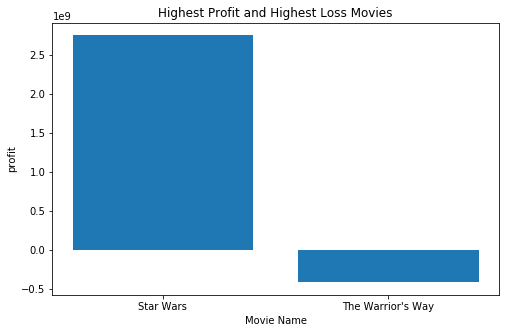

```python
df_mv["profit"] =  df_mv["revenue_adj"]- df_mv["budget_adj"]

#get the maximum profit
pr_max=df_mv.profit.max()
#get the highest loss
pr_min=df_mv.profit.min()

#To filter the highest profit and highest loss from df_mv dataframe.
df_pr_max_min=df_mv[df_mv["profit"].isin([pr_max,pr_min])]

# To draw the bar chart as below

plt.subplots(figsize=(8, 5))
plt.bar(df_pr_max_min.original_title, df_pr_max_min.profit)
plt.title('Highest Profit and Highest Loss Movies')
plt.xlabel('Movie Name')
plt.ylabel('profit');
plt.ylim=(0, 100)
plt.legend()
plt.show()
```